# Machine Learning Final Exam Project

##### Numerical Attribute Exploration

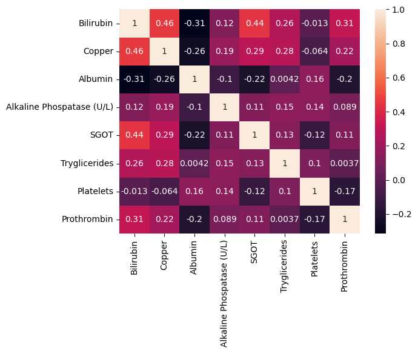

```python
# Check correlation between numeric columns
sns.heatmap(df1_numeric.corr(), annot=True)
plt.show()
```

Okay, it appears that the relationship between most of the feature are weak. The highest correlation observed between Bilirubin and Copper, indicating a potential link between this two variables, but overall nope. Let's plot the numerical attribute grouped by stages

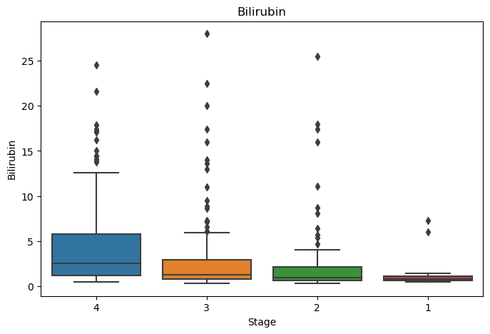

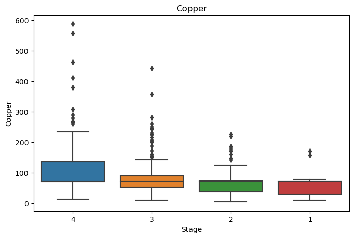

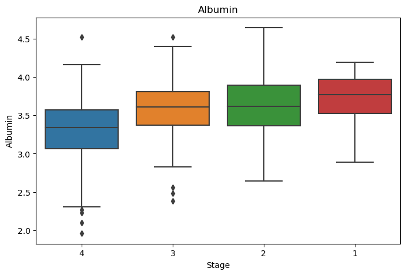

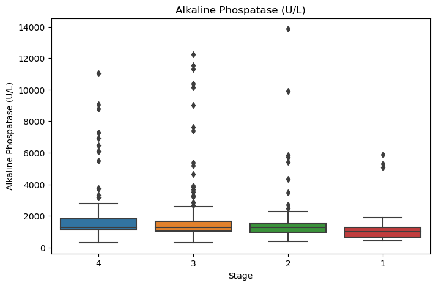

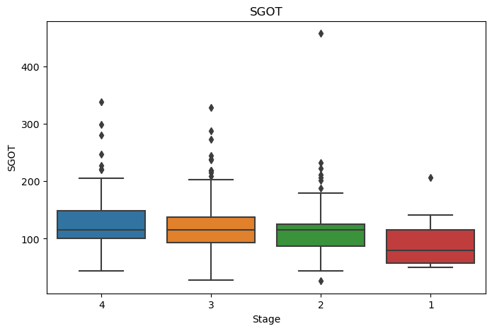

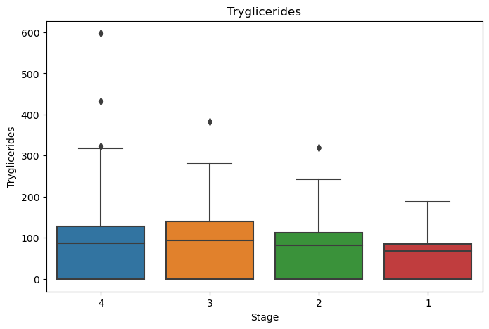

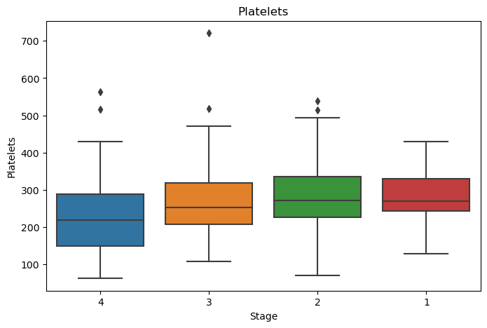

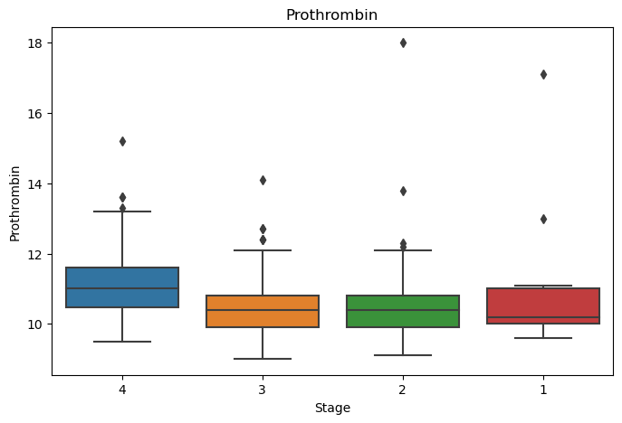

```python
def numerical_distribution(col):
    for i in col:
        plt.figure(figsize=(8,5))
        sns.boxplot(x=df1['Stage'], y = df1[i])
        plt.title(i)
        plt.show()

df1_num = ['Bilirubin','Copper', 'Albumin', 'Alkaline Phospatase (U/L)', 'SGOT', 'Tryglicerides', 'Platelets', 'Prothrombin']
numerical_distribution(df1_num)
# df1_numeric = df1[['Bilirubin', 'Copper', 'Albumin', 'Alkaline Phospatase (U/L)', 'SGOT', 'Tryglicerides', 'Platelets', 'Prothrombin']]
```

# Let's interpret this one by one

1. Bilirubin: Seen on the plot that as the stage progresses, Bilirubun levels also increases with stage 4 whosing the highest levels and variability. This tren suggest that Bilirubin could serve as a potential indicator of disease severity
1. Copper: Same as bilirubin, as the stage progresses, the Copper variability increases with stage 4 showing that there might be patient with overload copper level due to hepar failure, this could also indiicate that copper can be one of severity indicator
2. Albumin: Albumin level tend to decrease as the disease progresses, shown by the plot where the albumin level mean are dropping between stage 1 and 2, and between 3 and 4. this might happen because albumin are synthesised in the liver. As the liver condition worsen, the ability of liver in creating the albumin also decrease, indicating the organ failure
3. Alkaline Phosphatase: ALP are one of the enzyme processed in the liver as its job. Increasing number of ALP could be the sign of liver failure throughout the stage as the liver losing the ability in processing the enzyme
4. SGOT: SGOT are serum that help protein digestion in human body, increasing number of SGOT can be indication of organ failure especially heart, kidney, and liver. Slight increasement in the plot might proofing this as the stage progresses, might be a proof that the liver are unable to use this enzyme anymore due to organ failure
5. Triglycerides: Triglycerides are the type of fat in blood that come from food and liver> in the plot, it shows an increase through stages 1 - 3, and drop at stages 4. This might be an indicator that the progressive liver failure caused by the cirrhosis might make the triglycerides production unconditionable by the liver, thus making increasement in the number and then dropping at the stage 4 where the organ are totally failed in producing the Triglycerides
6. Platelets: Platelets number tend to drop progressively throughout the stages, this is caused by trombositopenia, a condition usually happen in hpatis cirrhosis patient. This happen because liver producing trombooitein as part of platelets, and when the liver lose it's ability due to organ failure, the number also tend to drop. This indicate that platelets could be indicator factor to measure the severity of hepatis cirrhosis
7. Prothrombin: Prothrombin are the time of blood takes to clot. Cirrhosis can cause the liver to produce fewer blood clotting proteins, leading to longer time needed for blood to clot, this are shown by the plot that the number of time in stage 4 increase rapidly, indicating patient in stage 4, due to liver failure, take longer time to finish the blood clotting

### 1.B. Model Training

### Preparing Data For Modeling

When using Random Forest and XGBoost, we generally don't need to scale the numerical feature because the algorithm are tree-based, keeping the numerical variable as it is might even bring more accuracy to the model. so we only process the categorical data

```python
for i in df1_cat:
    print(df1[i].value_counts())
    print()

#Seen here that the stage has become numerical
#let's keep encode them because we want our outcome to be classified, not regressed
```

```
Drug
D-penicillamine    264
Placebo            154
Name: count, dtype: int64

Gender
F    374
M     44
Name: count, dtype: int64

Ascites
N    394
Y     24
Name: count, dtype: int64

Hepatomegaly
Y    266
N    152
Name: count, dtype: int64

Edema
N    354
S     44
Y     20
Name: count, dtype: int64

Stage
3    161
4    144
2     92
1     21
Name: count, dtype: int64
```

```python
#Let's drop the status column first as we didn't need them anymore in training dataset
df1 = df1.drop(columns = ['Bilirubin_Status', 'Albumin_Status', 'Copper_Status', 'Alkaline_Phosphatase_Status', 'Triglycerides_Status', 'Platelets_Status', 'Prothrombin_Status', 'SGOT_Status'])
df1.head()
```

|  | Drug | Gender | Ascites | Hepatomegaly | Edema | Bilirubin | Albumin | Copper | Alkaline Phospatase (U/L) | SGOT | Tryglicerides | Platelets | Prothrombin | Stage |
| --- | --- | --- | --- | --- | --- | --- | --- | --- | --- | --- | --- | --- | --- | --- |
| 0 | D-penicillamine | F | Y | Y | Y | 14.5 | 2.60 | 156.0 | 1718.0 | 137.95 | 172.0 | 190.0 | 12.2 | 4 |
| 1 | D-penicillamine | F | N | Y | N | 1.1 | 4.14 | 54.0 | 7394.8 | 113.52 | 88.0 | 221.0 | 10.6 | 3 |
| 2 | D-penicillamine | M | N | N | S | 1.4 | 3.48 | 210.0 | 516.0 | 96.10 | 55.0 | 151.0 | 12.0 | 4 |
| 3 | D-penicillamine | F | N | Y | S | 1.8 | 2.54 | 64.0 | 6121.8 | 60.63 | 92.0 | 183.0 | 10.3 | 4 |
| 4 | Placebo | F | N | Y | N | 3.4 | 3.53 | 143.0 | 671.0 | 113.15 | 72.0 | 136.0 | 10.9 | 3 |

Encoding given for categorical variable depends on the type of the category, There are ordinal, binary, or multiclass

for binary categorical like gender or yes:no, we can use Label Encoding, it is suitable because there are only two categories. The feature we use label encoding are Drug, Gender, Ascites, and Hepatomegaly

for ordinal categorical like Edema with N, S, Y, it's best to use ordinal encoding, as there's natural order among the category such as No Edema < Some Edema (Relievable by drug) < Severe Edema (Although drug given), the other that will use ordinal encoder is Stage with 1, 2, 3, and 4 order. But due to natural order it got, Label Encoder can identify the order without needed to be mapped, thus we will use Label Encoder for all categorical variable

tree based model can handle the numeric label naturally, so there's no need to do One-Hot Encoding although there are no order in all the binary attribute

```python
#Encoding Categorical Variable

catcol = df1.select_dtypes(include=['object', 'category']).columns

label_encoder = LabelEncoder()

for i in catcol:
    df1[i] = label_encoder.fit_transform(df1[i])

df1.head()
```

|  | Drug | Gender | Ascites | Hepatomegaly | Edema | Bilirubin | Albumin | Copper | Alkaline Phospatase (U/L) | SGOT | Tryglicerides | Platelets | Prothrombin | Stage |
| --- | --- | --- | --- | --- | --- | --- | --- | --- | --- | --- | --- | --- | --- | --- |
| 0 | 0 | 0 | 1 | 1 | 2 | 14.5 | 2.60 | 156.0 | 1718.0 | 137.95 | 172.0 | 190.0 | 12.2 | 3 |
| 1 | 0 | 0 | 0 | 1 | 0 | 1.1 | 4.14 | 54.0 | 7394.8 | 113.52 | 88.0 | 221.0 | 10.6 | 2 |
| 2 | 0 | 1 | 0 | 0 | 1 | 1.4 | 3.48 | 210.0 | 516.0 | 96.10 | 55.0 | 151.0 | 12.0 | 3 |
| 3 | 0 | 0 | 0 | 1 | 1 | 1.8 | 2.54 | 64.0 | 6121.8 | 60.63 | 92.0 | 183.0 | 10.3 | 3 |
| 4 | 1 | 0 | 0 | 1 | 0 | 3.4 | 3.53 | 143.0 | 671.0 | 113.15 | 72.0 | 136.0 | 10.9 | 2 |

```python
#Train test split

x = df1.drop(columns=['Stage'])
y = df1['Stage']

x_train, x_test, y_train, y_test = train_test_split(x, y, test_size=0.2, random_state=42)
```

```python
#Creating analysis metrics

def run_it (model, x_train, x_test, y_train, y_test):
    model.fit(x_train, y_train)
    predx = model.predict(x_test)

    print(classification_report(y_test,predx))

    matrix = confusion_matrix(y_test,predx)
    disp = ConfusionMatrixDisplay(confusion_matrix=matrix, display_labels=model.classes_)
    disp.plot()
    plt.show()
```

### Initiate Modeling

```python
#Pre-GridSearch model initialization

#Random Forest
rf = RandomForestClassifier(random_state=123)
rf.fit(x_train, y_train)
rf_pred = rf.predict(x_test)

#XGBoost
xgbs = xgb.XGBClassifier()
xgbs.fit(x_train, y_train)
xgbs_pred = xgbs.predict(x_test)
```

```
              precision    recall  f1-score   support

           0       0.00      0.00      0.00         3
           1       0.09      0.06      0.07        16
           2       0.53      0.74      0.62        34
           3       0.69      0.58      0.63        31

    accuracy                           0.52        84
   macro avg       0.33      0.34      0.33        84
weighted avg       0.49      0.52      0.50        84
```

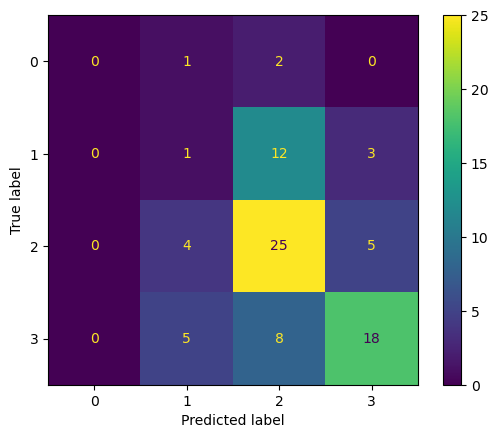

```python
#Random Forrest Pre-GridSearch Model Evaluation

run_it(rf,x_train, x_test, y_train, y_test)
```

```
              precision    recall  f1-score   support

           0       0.33      0.33      0.33         3
           1       0.12      0.06      0.08        16
           2       0.51      0.68      0.58        34
           3       0.64      0.58      0.61        31

    accuracy                           0.51        84
   macro avg       0.40      0.41      0.40        84
weighted avg       0.48      0.51      0.49        84
```

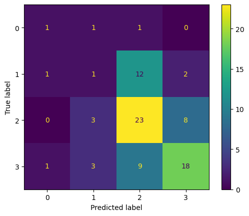

```python
#XGBoost Pre-GridSearch Model Evaluation

run_it(xgbs,x_train, x_test, y_train, y_test)
```

```python
#define parameter grids for rf and sgb

rf_param_grid = {
    'n_estimators': [50, 100, 200, 300],
    'max_depth': [5, 10, 20, 30, None],
    'min_samples_split': [2, 5, 10],
    'min_samples_leaf': [1, 2, 3, 4, 5],
    'criterion': ['gini', 'entropy', 'log_loss']
}

xgb_param_grid = {
    'n_estimators': [100, 200, 300],
    'max_depth': [3, 6, 9],
    'learning_rate': [0.01, 0.1, 0.2],
    'subsample': [0.2, 0.4, 0.5, 0.6, 0.8, 1.0],
    'colsample_bytree': [0.5, 0.6, 0.75, 0.8, 1.0],
    'gamma' : [0, 0.1, 0.2]
}
```

```python
# Grid search for random forest

rf_gridsearch = GridSearchCV(estimator = rf,
                             param_grid = rf_param_grid,
                             cv=3,
                             scoring='accuracy',
                             n_jobs=-1)
rf_gridsearch.fit(x_train, y_train)
```

```
GridSearchCV(cv=3, estimator=RandomForestClassifier(random_state=123),
             n_jobs=-1,
             param_grid={'criterion': ['gini', 'entropy', 'log_loss'],
                         'max_depth': [5, 10, 20, 30, None],
                         'min_samples_leaf': [1, 2, 3, 4, 5],
                         'min_samples_split': [2, 5, 10],
                         'n_estimators': [50, 100, 200, 300]},
             scoring='accuracy')
```

```python
# Grid search for xgboost


xgb_gridsearch = GridSearchCV(estimator = xgbs,
                              param_grid = xgb_param_grid,
                              cv=3,
                              n_jobs=-1,
                              scoring='accuracy')
xgb_gridsearch.fit(x_train, y_train)
```

```
GridSearchCV(cv=3,
             estimator=XGBClassifier(base_score=None, booster=None,
                                     callbacks=None, colsample_bylevel=None,
                                     colsample_bynode=None,
                                     colsample_bytree=None, device=None,
                                     early_stopping_rounds=None,
                                     enable_categorical=False, eval_metric=None,
                                     feature_types=None, gamma=None,
                                     grow_policy=None, importance_type=None,
                                     interaction_constraints=None,
                                     learning_rate=None,...
                                     missing=nan, monotone_constraints=None,
                                     multi_strategy=None, n_estimators=None,
                                     n_jobs=None, num_parallel_tree=None,
                                     objective='multi:softprob', ...),
             n_jobs=-1,
             param_grid={'colsample_bytree': [0.5, 0.6, 0.75, 0.8, 1.0],
                         'gamma': [0, 0.1, 0.2],
                         'learning_rate': [0.01, 0.1, 0.2],
                         'max_depth': [3, 6, 9],
                         'n_estimators': [100, 200, 300],
                         'subsample': [0.2, 0.4, 0.5, 0.6, 0.8, 1.0]},
             scoring='accuracy')
```

```python
#Printing Best Parameter

print('Random Forest Tuned Hyperparameter :', rf_gridsearch.best_params_)
print('Random Forest Best Accurracy: ', rf_gridsearch.best_score_)
print()
print('XGBoost Tuned Hyperparameter :', xgb_gridsearch.best_params_)
print('XGBoost Best Accurracy: ', xgb_gridsearch.best_score_)
```

```
Random Forest Tuned Hyperparameter : {'criterion': 'gini', 'max_depth': 10, 'min_samples_leaf': 5, 'min_samples_split': 2, 'n_estimators': 50}
Random Forest Best Accurracy:  0.5208065208065208

XGBoost Tuned Hyperparameter : {'colsample_bytree': 0.5, 'gamma': 0.1, 'learning_rate': 0.01, 'max_depth': 6, 'n_estimators': 300, 'subsample': 0.2}
XGBoost Best Accurracy:  0.5238899613899614
```

#### 1.C. Model Evaluation Metrics Analysis

```python
# Post-GridSearch model initialization

# Random Forest
from sklearn.ensemble import RandomForestClassifier

rf_2 = RandomForestClassifier(
    random_state=123,
    criterion='gini',
    max_depth=10,
    min_samples_leaf=5,
    min_samples_split=2,
    n_estimators=50
)
rf_2.fit(x_train, y_train)
rf_pred = rf_2.predict(x_test)

# XGBoost
import xgboost as xgb

xgbs_2 = xgb.XGBClassifier(
    colsample_bytree=0.5,
    gamma=0.1,
    learning_rate=0.01,
    max_depth=6,
    n_estimators=300,
    subsample=0.2,
    random_state=123
)
xgbs_2.fit(x_train, y_train)
xgbs_pred = xgbs_2.predict(x_test)
```

```
              precision    recall  f1-score   support

           0       0.00      0.00      0.00         3
           1       0.33      0.12      0.18        16
           2       0.57      0.76      0.65        34
           3       0.66      0.68      0.67        31

    accuracy                           0.58        84
   macro avg       0.39      0.39      0.37        84
weighted avg       0.53      0.58      0.54        84
```

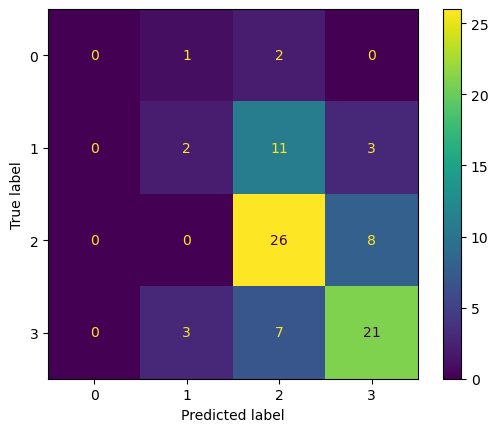

```python
#Random Forrest Post-GridSearch Model Evaluation

run_it(rf_2,x_train, x_test, y_train, y_test)
```

```
              precision    recall  f1-score   support

           0       0.00      0.00      0.00         3
           1       0.20      0.06      0.10        16
           2       0.53      0.76      0.63        34
           3       0.67      0.65      0.66        31

    accuracy                           0.56        84
   macro avg       0.35      0.37      0.34        84
weighted avg       0.50      0.56      0.51        84
```

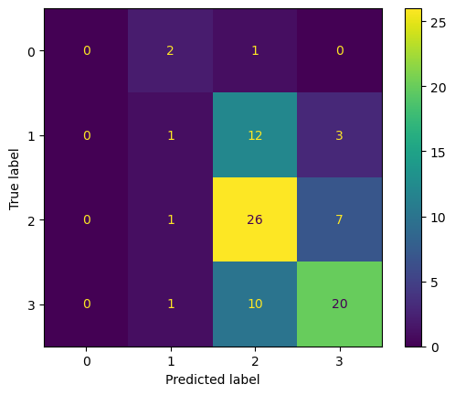

```python
#Random Forrest Post-GridSearch Model Evaluation

run_it(xgbs_2,x_train, x_test, y_train, y_test)
```

**Metrics Evaluation**

**Conclusion**

Random Forest slightly outperforms XGBoost in terms of accuracy, weighted F1-score, and macro averages. This suggests that Random Forest is marginally better at handling this dataset, despite both models struggling with minority classes.

#### 1.D. Model Evaluation

On the conclusion. we find that Random Forest are the best model between the 2 model we trained on this data. To find which feature contribute the most to the model, we can use SHAP for Feature Importance Analysis

```python
!pip show shap
```

```
Name: shap
Version: 0.46.0
Summary: A unified approach to explain the output of any machine learning model.
Home-page:
Author:
Author-email: Scott Lundberg <slund1@cs.washington.edu>
License: MIT License
Location: C:\Users\liana\anaconda3\Lib\site-packages
Requires: cloudpickle, numba, numpy, packaging, pandas, scikit-learn, scipy, slicer, tqdm
Required-by:
```

```python
import shap
```

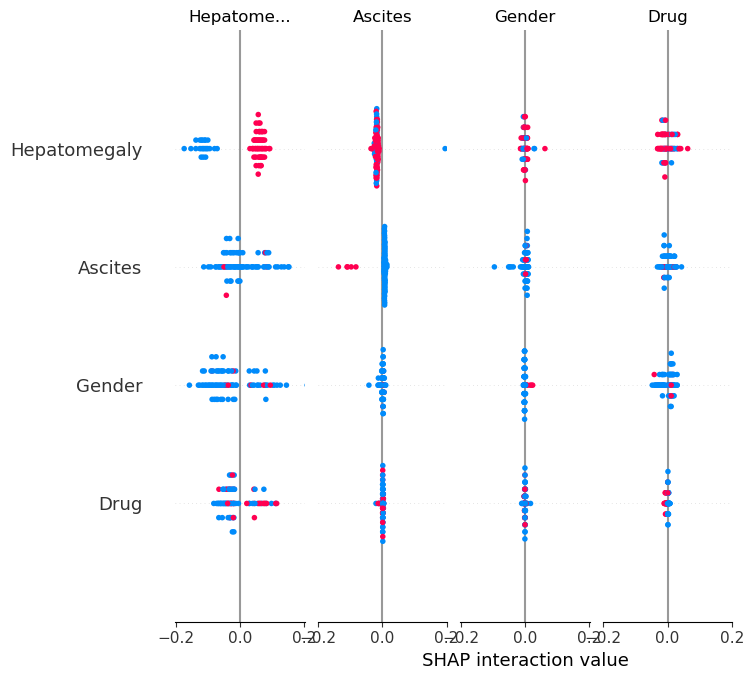

```python
# Initialize SHAP explainer for Random Forest
explainer_rf = shap.TreeExplainer(rf)
shap_values_rf = explainer_rf.shap_values(x_test)

# Visualize feature importance
shap.summary_plot(shap_values_rf, x_test, plot_type="bar", class_names=True)
```

**Interpretation of the SHAP**

The x-axis shows the SHAP interaction values, which represent how much each feature contributes to a particular prediction compared to the baseline (the expected model output). A positive SHAP value means the feature pushes the prediction higher, and a negative SHAP value means it pushes the prediction lower. The colors indicate the value of the feature. Red means higher values of the feature, and blue represents lower values. For example, in Hepatomegaly, the red points (higher values) are generally associated with positive SHAP values, suggesting that having Hepatomegaly is pushing the prediction higher.

**Key Observation**

```python
#For simpler one, we can utilize pandas

feature_importances = pd.DataFrame({
    'Feature': x_train.columns,
    'Importance': rf.feature_importances_
}).sort_values(by='Importance', ascending=False)
print(feature_importances)
```

```
                      Feature  Importance
6                     Albumin    0.148958
11                  Platelets    0.145653
12                Prothrombin    0.139013
5                   Bilirubin    0.115826
10              Tryglicerides    0.088135
8   Alkaline Phospatase (U/L)    0.086847
7                      Copper    0.083780
9                        SGOT    0.083181
3                Hepatomegaly    0.043424
4                       Edema    0.020391
0                        Drug    0.016955
2                     Ascites    0.015067
1                      Gender    0.012771
```

**Interpretation of Feature Importance Table**

1. The highest number shown by **Albumin** with 0.148958, meaninig that this feature contributes the most to the model prediction, followed by **Platelets** (0.145653) and **Prothrombin** (0.139013), which also have relatively high importance scores.
2. **Hepatomegaly, Edema, Drug, Ascites, and Gender** have relatively lower importance. These features are still part of the model but play a smaller role in predicting the target variable, as reflected by their lower scores.

The difference between FIT and SHAP might happen due to methodology difference of both metrics, FIT measures impact of a feature by looking at how much it reduces the impurity (Gini Index) in the decision trees during model training. It focuses on the contribution of each feature to the model as a whole. In the other hand, SHAP values show how much each feature, for each individual prediction, contributes to the final output. This means that SHAP values can capture interactions and non-linearities between features that are not easily reflected by the FIT metric.